# Case Study 01 PART 1

## Loading the dataset and descriptive statistics

Let's import the dataset

```python
import pandas as pd

tayko_df = pd.read_csv('Tayko.csv')
tayko_df
```

|  | sequence_number | US | source_a | source_c | source_b | source_d | source_e | source_m | source_o | source_h | ... | source_x | source_w | Freq | last_update_days_ago | 1st_update_days_ago | Web order | Gender=male | Address_is_res | Purchase | Spending |
| --- | --- | --- | --- | --- | --- | --- | --- | --- | --- | --- | --- | --- | --- | --- | --- | --- | --- | --- | --- | --- | --- |
| 0 | 1 | 1 | 0 | 0 | 1 | 0 | 0 | 0 | 0 | 0 | ... | 0 | 0 | 2 | 3662 | 3662 | 1 | 0 | 1 | 1 | 128 |
| 1 | 2 | 1 | 0 | 0 | 0 | 0 | 1 | 0 | 0 | 0 | ... | 0 | 0 | 0 | 2900 | 2900 | 1 | 1 | 0 | 0 | 0 |
| 2 | 3 | 1 | 0 | 0 | 0 | 0 | 0 | 0 | 0 | 0 | ... | 0 | 0 | 2 | 3883 | 3914 | 0 | 0 | 0 | 1 | 127 |
| 3 | 4 | 1 | 0 | 1 | 0 | 0 | 0 | 0 | 0 | 0 | ... | 0 | 0 | 1 | 829 | 829 | 0 | 1 | 0 | 0 | 0 |
| 4 | 5 | 1 | 0 | 1 | 0 | 0 | 0 | 0 | 0 | 0 | ... | 0 | 0 | 1 | 869 | 869 | 0 | 0 | 0 | 0 | 0 |
| ... | ... | ... | ... | ... | ... | ... | ... | ... | ... | ... | ... | ... | ... | ... | ... | ... | ... | ... | ... | ... | ... |
| 1995 | 1996 | 1 | 0 | 0 | 0 | 0 | 0 | 0 | 0 | 0 | ... | 0 | 0 | 1 | 1701 | 1701 | 1 | 0 | 0 | 1 | 30 |
| 1996 | 1997 | 1 | 0 | 0 | 0 | 0 | 0 | 0 | 0 | 0 | ... | 0 | 0 | 1 | 2633 | 2633 | 1 | 1 | 0 | 1 | 10 |
| 1997 | 1998 | 1 | 0 | 0 | 0 | 0 | 0 | 0 | 0 | 0 | ... | 0 | 0 | 0 | 3394 | 3394 | 0 | 0 | 0 | 0 | 0 |
| 1998 | 1999 | 1 | 0 | 0 | 0 | 0 | 0 | 0 | 0 | 0 | ... | 0 | 1 | 1 | 253 | 253 | 0 | 1 | 1 | 0 | 0 |
| 1999 | 2000 | 1 | 0 | 0 | 0 | 0 | 0 | 0 | 0 | 0 | ... | 0 | 0 | 1 | 1261 | 1844 | 0 | 0 | 0 | 0 | 0 |

2000 rows × 25 columns

Let's have a look to the shape of the dataset

```python
print('Takyo_df dimensions')
print('n of rows: ', tayko_df.shape[0], ', n of columns: ', tayko_df.shape[1])
```

```
Takyo_df dimensions
n of rows:  2000 , n of columns:  25
```

Let's look at the type of variables

```python
tayko_df.dtypes
```

```
sequence_number         int64
US                      int64
source_a                int64
source_c                int64
source_b                int64
source_d                int64
source_e                int64
source_m                int64
source_o                int64
source_h                int64
source_r                int64
source_s                int64
source_t                int64
source_u                int64
source_p                int64
source_x                int64
source_w                int64
Freq                    int64
last_update_days_ago    int64
1st_update_days_ago     int64
Web order               int64
Gender=male             int64
Address_is_res          int64
Purchase                int64
Spending                int64
dtype: object
```

There are no missing values in the dataset

```python
print('N of missing values')
tayko_df.isnull().sum()
```

```
N of missing values
```

```
sequence_number         0
US                      0
source_a                0
source_c                0
source_b                0
source_d                0
source_e                0
source_m                0
source_o                0
source_h                0
source_r                0
source_s                0
source_t                0
source_u                0
source_p                0
source_x                0
source_w                0
Freq                    0
last_update_days_ago    0
1st_update_days_ago     0
Web order               0
Gender=male             0
Address_is_res          0
Purchase                0
Spending                0
dtype: int64
```

Rename of Gender and Web_order because blank spaces may cause problems.

```python
tayko_df = tayko_df.rename(columns={'Gender=male': 'Gender'})
tayko_df = tayko_df.rename(columns={'Web order': 'Web_order'})

tayko_df = tayko_df.drop(['sequence_number'], axis=1)

tayko_df.dtypes
```

```
US                      int64
source_a                int64
source_c                int64
source_b                int64
source_d                int64
source_e                int64
source_m                int64
source_o                int64
source_h                int64
source_r                int64
source_s                int64
source_t                int64
source_u                int64
source_p                int64
source_x                int64
source_w                int64
Freq                    int64
last_update_days_ago    int64
1st_update_days_ago     int64
Web_order               int64
Gender                  int64
Address_is_res          int64
Purchase                int64
Spending                int64
dtype: object
```

all the variables are integer, but even though they're integers it doesn't mean they're all numerical. This depends on how they were coded. Binary variables have 2 outcomes, often coded as 0 and 1 (like in our case). Because of this, the software recognize them as numerical variables, even though they're categorical/Binary. Here a list of the categorical variables :

- source* (all the source variables)
- US
- Web_order
- Gender
- Address_is_res

List of unique values per variable

```python
print('Number of unique values per variable')

tayko_df.nunique()
```

```
Number of unique values per variable
```

```
US                        2
source_a                  2
source_c                  2
source_b                  2
source_d                  2
source_e                  2
source_m                  2
source_o                  2
source_h                  2
source_r                  2
source_s                  2
source_t                  2
source_u                  2
source_p                  2
source_x                  2
source_w                  2
Freq                     15
last_update_days_ago    940
1st_update_days_ago     923
Web_order                 2
Gender                    2
Address_is_res            2
Purchase                  2
Spending                363
dtype: int64
```

```python
print('Descriptive statistics for numerical variables')
tayko_df[['Freq','last_update_days_ago', '1st_update_days_ago', 'Spending']].describe()
```

```
Descriptive statistics for numerical variables
```

|  | Freq | last_update_days_ago | 1st_update_days_ago | Spending |
| --- | --- | --- | --- | --- |
| count | 2000.000000 | 2000.000000 | 2000.000000 | 2000.00000 |
| mean | 1.417000 | 2155.101000 | 2435.601500 | 102.62500 |
| std | 1.405738 | 1141.302846 | 1077.872233 | 186.78261 |
| min | 0.000000 | 1.000000 | 1.000000 | 0.00000 |
| 25% | 1.000000 | 1133.000000 | 1671.250000 | 0.00000 |
| 50% | 1.000000 | 2280.000000 | 2721.000000 | 2.00000 |
| 75% | 2.000000 | 3139.250000 | 3353.000000 | 153.00000 |
| max | 15.000000 | 4188.000000 | 4188.000000 | 1500.00000 |

Distribution of True (1) and False (0) in the binary variables

```python
a = tayko_df.drop(['Freq','last_update_days_ago', '1st_update_days_ago', 'Spending'], 1)

print(a.apply(pd.Series.value_counts))
```

```
     US  source_a  source_c  source_b  source_d  source_e  source_m  source_o  \
0   351      1747      1888      1880      1917      1698      1967      1933
1  1649       253       112       120        83       302        33        67

   source_h  source_r  source_s  source_t  source_u  source_p  source_x  \
0      1895      1863      1906      1957      1762      1988      1964
1       105       137        94        43       238        12        36

   source_w  Web_order  Gender  Address_is_res  Purchase
0      1725       1148     951            1558      1000
1       275        852    1049             442      1000
```

## Looking at the Correlations

Let's have a look to the correlation matrix. Since the correlation can be omputed just with numerical values, we decided to leave out all the dummy variables (except for Purchase that is the target variable).

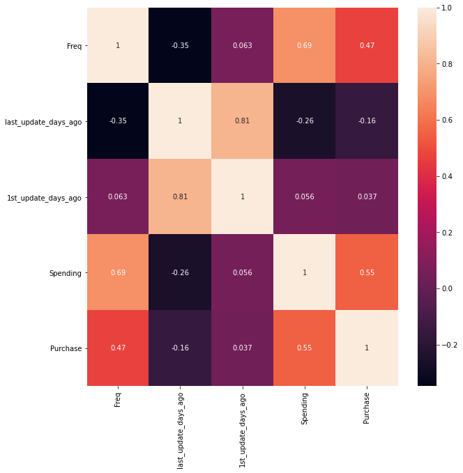

```python
import pandas as pd
import seaborn as sn
import matplotlib.pyplot as plt

plt.figure(figsize=(10,10))

corrMatrix = tayko_df[['Freq','last_update_days_ago','1st_update_days_ago','Spending', 'Purchase']].corr()
sn.heatmap(corrMatrix, annot=True)
plt.show()
```

https://www.statisticshowto.com/phi-coefficient-mean-square-contingency-coefficient/#:~:text=The%20Phi%20Coefficient%20is%20a,variable%20is%20a%20nominal%20variable.

[output not shown]

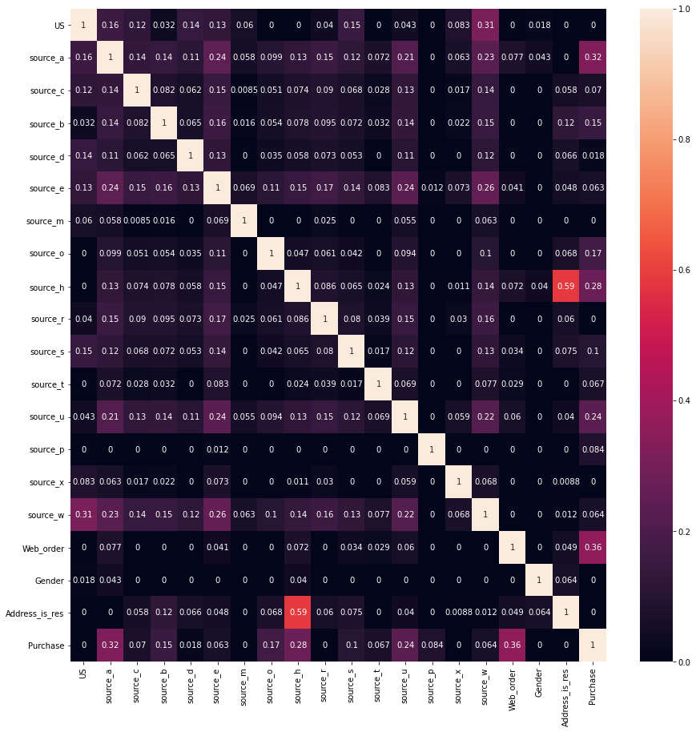

```python
import pandas as pd
import phik
from phik import resources, report

a.phik_matrix()

plt.figure(figsize=(15,15))

corrMatrix = a.phik_matrix()
sn.heatmap(corrMatrix, annot=True)
plt.show()
```

It seems that Purchase shows the highest correlation with "Freq" and "Spending". "1st_update_days_ago" doesn't seem to be correlated to the target variable and "last_update_days_ago" shows a weak correlation.

In addition, "freq" and "spending" show a high correlation. Using both at the same time may lead to multicollinearity problems.

Let's see the descriptive statistics for the top 5 variales when purchase = 0 and purchase = 1

```python
top_5 = tayko_df[['Freq','Spending', 'Web_order', 'source_a','source_u', 'source_h', 'Purchase']]
top_5_0 = top_5[top_5["Purchase"] == 0]
top_5_1 = top_5[top_5["Purchase"] == 1]

print('Variables when Purchase = 0' )
top_5_0.describe()
```

```
Variables when Purchase = 0
```

|  | Freq | Spending | Web_order | source_a | source_u | source_h | Purchase |
| --- | --- | --- | --- | --- | --- | --- | --- |
| count | 1000.000000 | 1000.000000 | 1000.000000 | 1000.000000 | 1000.000000 | 1000.000000 | 1000.0 |
| mean | 0.757000 | 0.001000 | 0.308000 | 0.056000 | 0.069000 | 0.093000 | 0.0 |
| std | 0.725588 | 0.031623 | 0.461898 | 0.230037 | 0.253581 | 0.290578 | 0.0 |
| min | 0.000000 | 0.000000 | 0.000000 | 0.000000 | 0.000000 | 0.000000 | 0.0 |
| 25% | 0.000000 | 0.000000 | 0.000000 | 0.000000 | 0.000000 | 0.000000 | 0.0 |
| 50% | 1.000000 | 0.000000 | 0.000000 | 0.000000 | 0.000000 | 0.000000 | 0.0 |
| 75% | 1.000000 | 0.000000 | 1.000000 | 0.000000 | 0.000000 | 0.000000 | 0.0 |
| max | 4.000000 | 1.000000 | 1.000000 | 1.000000 | 1.000000 | 1.000000 | 0.0 |

```python
print('Variables when Purchase = 1' )
top_5_1.describe()
```

```
Variables when Purchase = 1
```

|  | Freq | Spending | Web_order | source_a | source_u | source_h | Purchase |
| --- | --- | --- | --- | --- | --- | --- | --- |
| count | 1000.000000 | 1000.000000 | 1000.000000 | 1000.000000 | 1000.000000 | 1000.00000 | 1000.0 |
| mean | 2.077000 | 205.249000 | 0.544000 | 0.197000 | 0.169000 | 0.01200 | 1.0 |
| std | 1.598633 | 220.739559 | 0.498309 | 0.397931 | 0.374939 | 0.10894 | 0.0 |
| min | 1.000000 | 3.000000 | 0.000000 | 0.000000 | 0.000000 | 0.00000 | 1.0 |
| 25% | 1.000000 | 94.750000 | 0.000000 | 0.000000 | 0.000000 | 0.00000 | 1.0 |
| 50% | 2.000000 | 153.000000 | 1.000000 | 0.000000 | 0.000000 | 0.00000 | 1.0 |
| 75% | 2.250000 | 233.750000 | 1.000000 | 0.000000 | 0.000000 | 0.00000 | 1.0 |
| max | 15.000000 | 1500.000000 | 1.000000 | 1.000000 | 1.000000 | 1.00000 | 1.0 |

The descriptive variables for purchase = 0 and purchase = 1 are way different. This means that there may be substantial differences between the two groups. Let's try to see if the visualization can plot this differences.

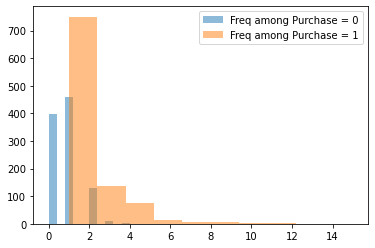

```python
import random
import numpy
from matplotlib import pyplot

pyplot.hist(top_5_0.Freq, alpha=0.5, label='Freq among Purchase = 0')
pyplot.hist(top_5_1.Freq, alpha=0.5, label='Freq among Purchase = 1')
pyplot.legend(loc='upper right')
pyplot.show()
```

The descriptive variables for purchase = 0 and purchase = 1 are way different. This means that there may be substantial differences between the two groups

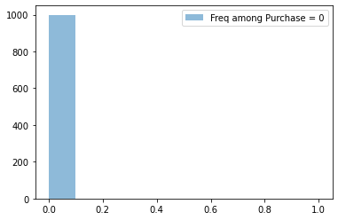

```python
import random
import numpy
from matplotlib import pyplot

pyplot.hist(top_5_0.Spending, alpha=0.5, label='Freq among Purchase = 0')
# pyplot.hist(top_5_1.Spending, alpha=0.5, label='Freq among Purchase = 1')
pyplot.legend(loc='upper right')
pyplot.show()
```

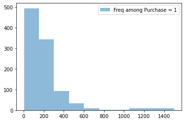

```python
import random
import numpy
from matplotlib import pyplot

#pyplot.hist(top_5_0.Spending, alpha=0.5, label='Freq among Purchase = 0')
pyplot.hist(top_5_1.Spending, alpha=0.5, label='Freq among Purchase = 1')
pyplot.legend(loc='upper right')
pyplot.show()
```

```python
print('Distribution of source_a between purchase = 0 and Purchase=1' )
pd.DataFrame(tayko_df.groupby(['source_a', 'Purchase']).size())
```

```
Distribution of source_a between purchase = 0 and Purchase=1
```

| source_a | Purchase | 0 |
| --- | --- | --- |
| 0 | 0 | 944 |
|  | 1 | 803 |
| 1 | 0 | 56 |
|  | 1 | 197 |

```python
print('Distribution of source_h between purchase = 0 and Purchase=1' )
pd.DataFrame(tayko_df.groupby(['source_h', 'Purchase']).size())
```

```
Distribution of source_h between purchase = 0 and Purchase=1
```

| source_h | Purchase | 0 |
| --- | --- | --- |
| 0 | 0 | 907 |
|  | 1 | 988 |
| 1 | 0 | 93 |
|  | 1 | 12 |

```python
print('Distribution of source_u between purchase = 0 and Purchase=1' )
pd.DataFrame(tayko_df.groupby(['source_u', 'Purchase']).size())
```

```
Distribution of source_u between purchase = 0 and Purchase=1
```

| source_u | Purchase | 0 |
| --- | --- | --- |
| 0 | 0 | 931 |
|  | 1 | 831 |
| 1 | 0 | 69 |
|  | 1 | 169 |

We can conclude thatare significant differences in the distribution of these 5 variables between purchasers and not.

## PCA

### Standardization

Let's standardize the variables

```python
# exclude a data type
df_num = tayko_df[['Freq','last_update_days_ago','1st_update_days_ago','Spending']]
df_cat = tayko_df.drop(['Freq','last_update_days_ago','1st_update_days_ago','Spending'], axis=1)

import pandas as pd
from sklearn import preprocessing

x = df_num.values #returns a numpy array
min_max_scaler = preprocessing.MinMaxScaler()
x_scaled = min_max_scaler.fit_transform(x)
df_scaled = pd.DataFrame(x_scaled)
df_scaled.columns = ['Freq', 'last_update_days_ago', '1st_update_days_ago', 'Spending']


scaled_df = pd.concat([df_scaled.reset_index(drop=True),df_cat.reset_index(drop=True)], axis=1)

scaled_df
```

|  | Freq | last_update_days_ago | 1st_update_days_ago | Spending | US | source_a | source_c | source_b | source_d | source_e | ... | source_s | source_t | source_u | source_p | source_x | source_w | Web_order | Gender | Address_is_res | Purchase |
| --- | --- | --- | --- | --- | --- | --- | --- | --- | --- | --- | --- | --- | --- | --- | --- | --- | --- | --- | --- | --- | --- |
| 0 | 0.133333 | 0.874373 | 0.874373 | 0.085333 | 1 | 0 | 0 | 1 | 0 | 0 | ... | 0 | 0 | 0 | 0 | 0 | 0 | 1 | 0 | 1 | 1 |
| 1 | 0.000000 | 0.692381 | 0.692381 | 0.000000 | 1 | 0 | 0 | 0 | 0 | 1 | ... | 0 | 0 | 0 | 0 | 0 | 0 | 1 | 1 | 0 | 0 |
| 2 | 0.133333 | 0.927155 | 0.934559 | 0.084667 | 1 | 0 | 0 | 0 | 0 | 0 | ... | 0 | 1 | 0 | 0 | 0 | 0 | 0 | 0 | 0 | 1 |
| 3 | 0.066667 | 0.197755 | 0.197755 | 0.000000 | 1 | 0 | 1 | 0 | 0 | 0 | ... | 0 | 0 | 0 | 0 | 0 | 0 | 0 | 1 | 0 | 0 |
| 4 | 0.066667 | 0.207308 | 0.207308 | 0.000000 | 1 | 0 | 1 | 0 | 0 | 0 | ... | 0 | 0 | 0 | 0 | 0 | 0 | 0 | 0 | 0 | 0 |
| ... | ... | ... | ... | ... | ... | ... | ... | ... | ... | ... | ... | ... | ... | ... | ... | ... | ... | ... | ... | ... | ... |
| 1995 | 0.066667 | 0.406019 | 0.406019 | 0.020000 | 1 | 0 | 0 | 0 | 0 | 0 | ... | 0 | 0 | 1 | 0 | 0 | 0 | 1 | 0 | 0 | 1 |
| 1996 | 0.066667 | 0.628612 | 0.628612 | 0.006667 | 1 | 0 | 0 | 0 | 0 | 0 | ... | 1 | 0 | 0 | 0 | 0 | 0 | 1 | 1 | 0 | 1 |
| 1997 | 0.000000 | 0.810365 | 0.810365 | 0.000000 | 1 | 0 | 0 | 0 | 0 | 0 | ... | 0 | 0 | 0 | 0 | 0 | 0 | 0 | 0 | 0 | 0 |
| 1998 | 0.066667 | 0.060186 | 0.060186 | 0.000000 | 1 | 0 | 0 | 0 | 0 | 0 | ... | 0 | 0 | 0 | 0 | 0 | 1 | 0 | 1 | 1 | 0 |
| 1999 | 0.066667 | 0.300931 | 0.440172 | 0.000000 | 1 | 0 | 0 | 0 | 0 | 0 | ... | 0 | 0 | 0 | 0 | 0 | 0 | 0 | 0 | 0 | 0 |

2000 rows × 24 columns

### PCA Analysis and evaluation

```python
from sklearn.decomposition import PCA
import numpy as np
pca = PCA()
pca.fit(scaled_df)
cumsum = np.cumsum(pca.explained_variance_ratio_)
d = np.argmax(cumsum >= 0.95) + 1

print('Number of PC necessary to have 95% of explained variance: ', d)
```

```
Number of PC necessary to have 95% of explained variance:  16
```

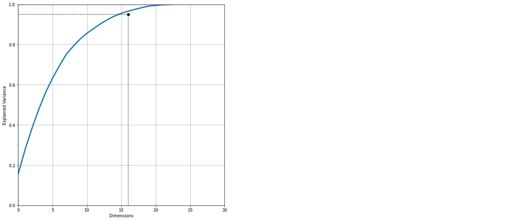

```python
import pandas as pd
import seaborn as sn
import matplotlib.pyplot as plt

plt.figure(figsize=(9,9))
plt.plot(cumsum, linewidth=3)
plt.axis([0, 30, 0, 1])
plt.xlabel("Dimensions")
plt.ylabel("Explained Variance")
plt.plot([d, d], [0, 0.95], "k:")
plt.plot([0, d], [0.95, 0.95], "k:")
plt.plot(d, 0.95, "ko")
plt.annotate("Elbow", xy=(65, 0.85), xytext=(70, 0.7),
             arrowprops=dict(arrowstyle="->"), fontsize=16)
plt.grid(True)
plt.show()
```

```python
print('cumulated count of the variance explained by PC')
pd.DataFrame(np.array([pca.explained_variance_ratio_[:i].sum() for i in range(1, d+1)]).round(3))
```

```
cumulated count of the variance explained by PC
```

|  | 0 |
| --- | --- |
| 0 | 0.155 |
| 1 | 0.277 |
| 2 | 0.382 |
| 3 | 0.478 |
| 4 | 0.563 |
| 5 | 0.633 |
| 6 | 0.694 |
| 7 | 0.752 |
| 8 | 0.791 |
| 9 | 0.827 |
| 10 | 0.856 |
| 11 | 0.880 |
| 12 | 0.904 |
| 13 | 0.924 |
| 14 | 0.942 |
| 15 | 0.955 |

Here is how the dataset appear once the PCA are applied

```python
pca = PCA(n_components=9)
principalComponents = pca.fit_transform(scaled_df)
tayko_PCA = pd.DataFrame(principalComponents, columns=['PC1', 'PC2', 'PC3','PC4', 'PC5',
                                                       'PC6', 'PC7','PC8', 'PC9'])

tayko_PCA.index=scaled_df.index

tayko_PCA
```

|  | PC1 | PC2 | PC3 | PC4 | PC5 | PC6 | PC7 | PC8 | PC9 |
| --- | --- | --- | --- | --- | --- | --- | --- | --- | --- |
| 0 | 0.647009 | 0.535844 | -0.186893 | 0.032214 | -0.699161 | 0.272559 | 0.303770 | 0.123520 | 0.744508 |
| 1 | -0.151907 | -0.565811 | -0.392689 | 0.732671 | -0.136555 | 0.533609 | -0.541547 | -0.148489 | -0.170841 |
| 2 | 0.113625 | 0.391210 | -0.526449 | -0.628526 | 0.175218 | -0.084035 | 0.021297 | -0.003653 | 0.404276 |
| 3 | -0.658924 | -0.429910 | 0.267304 | 0.031448 | 0.036167 | -0.447338 | -0.291906 | -0.239046 | -0.231585 |
| 4 | -0.613882 | 0.524657 | -0.000608 | 0.048516 | 0.082118 | -0.541285 | -0.314160 | -0.193303 | -0.241367 |
| ... | ... | ... | ... | ... | ... | ... | ... | ... | ... |
| 1995 | 0.842560 | 0.443220 | -0.265406 | 0.106373 | 0.070313 | -0.211479 | 0.306305 | -0.715663 | -0.354817 |
| 1996 | 0.646302 | -0.554530 | -0.134246 | 0.153786 | -0.092352 | -0.151617 | -0.148490 | -0.160354 | 0.205239 |
| 1997 | -0.648527 | 0.411542 | -0.510366 | -0.067555 | 0.012668 | -0.256828 | 0.028445 | 0.028085 | 0.073089 |
| 1998 | -0.622116 | -0.143362 | 1.327927 | 0.050358 | -0.211667 | -0.265565 | -0.164138 | 0.033818 | -0.080927 |
| 1999 | -0.603648 | 0.510984 | -0.130701 | -0.038714 | 0.024073 | -0.418009 | -0.162573 | -0.119983 | 0.264762 |

2000 rows × 9 columns

Instead here we have the loading matrix

```python
loadings = pd.DataFrame(pca.components_.T, columns=['PC1', 'PC2', 'PC3','PC4', 'PC5',
                                                       'PC6', 'PC7','PC8', 'PC9'],
             index = scaled_df.columns.values.tolist())
print('Loading matrix')
loadings
```

```
Loading matrix
```

|  | PC1 | PC2 | PC3 | PC4 | PC5 | PC6 | PC7 | PC8 | PC9 |
| --- | --- | --- | --- | --- | --- | --- | --- | --- | --- |
| Freq | 0.068918 | 0.014839 | 0.034849 | -0.061959 | -0.024455 | 0.025045 | -0.004847 | 0.007307 | -0.005629 |
| last_update_days_ago | -0.078361 | -0.092964 | -0.413319 | -0.026425 | -0.064211 | 0.129901 | 0.211946 | 0.110576 | 0.229818 |
| 1st_update_days_ago | 0.009109 | -0.092519 | -0.396642 | -0.110087 | -0.096058 | 0.149117 | 0.202130 | 0.121795 | 0.195664 |
| Spending | 0.108262 | 0.004108 | 0.015100 | -0.083288 | 0.031544 | 0.007951 | -0.011957 | 0.000006 | -0.000787 |
| US | 0.023819 | -0.072422 | -0.179924 | -0.207516 | -0.511106 | -0.441334 | -0.508575 | -0.319877 | -0.000354 |
| source_a | 0.152882 | -0.083662 | -0.146152 | -0.238918 | -0.151372 | -0.110626 | 0.014254 | 0.663999 | -0.531325 |
| source_c | -0.011712 | 0.000272 | 0.018983 | 0.037879 | -0.025569 | -0.117851 | -0.092567 | -0.081710 | -0.057426 |
| source_b | -0.044620 | -0.023889 | -0.113491 | 0.039897 | 0.000507 | -0.016678 | 0.131873 | 0.069847 | 0.378498 |
| source_d | 0.002681 | -0.014261 | -0.054283 | -0.024679 | -0.022784 | -0.037660 | -0.004373 | -0.018913 | 0.168424 |
| source_e | -0.077927 | 0.015500 | -0.128775 | 0.067286 | 0.137659 | 0.699523 | -0.552042 | -0.119562 | -0.183738 |
| source_m | 0.000157 | -0.005520 | 0.002161 | -0.009476 | -0.007180 | -0.013419 | -0.010338 | -0.012594 | 0.019799 |
| source_o | -0.034594 | -0.014321 | -0.059617 | 0.020994 | -0.014203 | -0.014330 | 0.050951 | 0.024951 | 0.090873 |
| source_h | -0.072912 | 0.066452 | 0.135293 | 0.020922 | -0.215536 | 0.060406 | 0.075633 | 0.010940 | -0.030439 |
| source_r | 0.003737 | 0.016845 | 0.019950 | -0.021244 | -0.055235 | -0.041470 | -0.007894 | -0.047132 | 0.381565 |
| source_s | -0.029437 | 0.005912 | -0.013496 | 0.008832 | -0.019645 | -0.098692 | -0.060496 | -0.053706 | 0.005534 |
| source_t | 0.011832 | -0.008342 | -0.013568 | -0.004457 | -0.010144 | 0.006008 | 0.016325 | 0.002572 | 0.066391 |
| source_u | 0.104258 | 0.005988 | -0.064972 | -0.086222 | 0.059448 | 0.000082 | 0.512845 | -0.600752 | -0.445819 |
| source_p | 0.007337 | 0.000804 | -0.006999 | -0.003176 | 0.003461 | 0.002167 | 0.004725 | 0.001881 | 0.019252 |
| source_x | -0.000044 | -0.005335 | -0.004566 | 0.001899 | -0.024468 | -0.009297 | -0.002461 | -0.008468 | 0.030063 |
| source_w | 0.041474 | 0.053191 | 0.465112 | 0.164783 | 0.340453 | -0.265613 | -0.093437 | 0.163886 | 0.075676 |
| Web_order | 0.612081 | -0.058398 | -0.109284 | 0.735205 | -0.258309 | 0.027224 | 0.004695 | 0.013933 | -0.023832 |
| Gender | -0.045704 | -0.956338 | 0.260174 | -0.018372 | -0.047482 | 0.096612 | 0.026210 | -0.043523 | 0.013849 |
| Address_is_res | -0.025905 | 0.208111 | 0.503069 | -0.126774 | -0.635905 | 0.367916 | 0.185602 | 0.059228 | 0.076075 |
| Purchase | 0.739985 | 0.008028 | 0.089091 | -0.524447 | 0.192710 | 0.129071 | -0.071676 | -0.063357 | 0.214396 |

### Correlation between loadings and variables

```python
loadings = pca.components_.T * np.sqrt(pca.explained_variance_)

loading_matrix = pd.DataFrame(loadings, columns=['PC1', 'PC2', 'PC3','PC4', 'PC5',
                                                       'PC6', 'PC7','PC8', 'PC9'],
             index = scaled_df.columns.values.tolist())
loading_matrix
```

|  | PC1 | PC2 | PC3 | PC4 | PC5 | PC6 | PC7 | PC8 | PC9 |
| --- | --- | --- | --- | --- | --- | --- | --- | --- | --- |
| Freq | 0.039267 | 0.007468 | 0.016393 | -0.027622 | -0.010304 | 0.009594 | -0.001739 | 0.002527 | -0.001613 |
| last_update_days_ago | -0.044648 | -0.046786 | -0.194424 | -0.011781 | -0.027056 | 0.049761 | 0.076049 | 0.038242 | 0.065873 |
| 1st_update_days_ago | 0.005190 | -0.046562 | -0.186579 | -0.049078 | -0.040475 | 0.057122 | 0.072527 | 0.042122 | 0.056083 |
| Spending | 0.061685 | 0.002067 | 0.007103 | -0.037130 | 0.013291 | 0.003046 | -0.004290 | 0.000002 | -0.000226 |
| US | 0.013571 | -0.036448 | -0.084635 | -0.092512 | -0.215358 | -0.169062 | -0.182484 | -0.110628 | -0.000101 |
| source_a | 0.087108 | -0.042104 | -0.068749 | -0.106511 | -0.063782 | -0.042378 | 0.005114 | 0.229641 | -0.152293 |
| source_c | -0.006673 | 0.000137 | 0.008930 | 0.016887 | -0.010774 | -0.045145 | -0.033214 | -0.028259 | -0.016460 |
| source_b | -0.025424 | -0.012023 | -0.053386 | 0.017786 | 0.000214 | -0.006389 | 0.047318 | 0.024156 | 0.108489 |
| source_d | 0.001528 | -0.007177 | -0.025534 | -0.011002 | -0.009600 | -0.014426 | -0.001569 | -0.006541 | 0.048275 |
| source_e | -0.044401 | 0.007801 | -0.060575 | 0.029997 | 0.058003 | 0.267967 | -0.198080 | -0.041350 | -0.052665 |
| source_m | 0.000090 | -0.002778 | 0.001017 | -0.004224 | -0.003025 | -0.005140 | -0.003709 | -0.004356 | 0.005675 |
| source_o | -0.019711 | -0.007207 | -0.028044 | 0.009359 | -0.005984 | -0.005489 | 0.018282 | 0.008629 | 0.026047 |
| source_h | -0.041543 | 0.033443 | 0.063641 | 0.009327 | -0.090818 | 0.023140 | 0.027138 | 0.003784 | -0.008725 |
| source_r | 0.002129 | 0.008477 | 0.009384 | -0.009471 | -0.023274 | -0.015886 | -0.002832 | -0.016301 | 0.109368 |
| source_s | -0.016772 | 0.002975 | -0.006349 | 0.003937 | -0.008278 | -0.037806 | -0.021707 | -0.018574 | 0.001586 |
| source_t | 0.006741 | -0.004198 | -0.006382 | -0.001987 | -0.004274 | 0.002301 | 0.005858 | 0.000890 | 0.019030 |
| source_u | 0.059404 | 0.003014 | -0.030563 | -0.038438 | 0.025049 | 0.000031 | 0.184016 | -0.207768 | -0.127785 |
| source_p | 0.004181 | 0.000405 | -0.003292 | -0.001416 | 0.001458 | 0.000830 | 0.001696 | 0.000651 | 0.005518 |
| source_x | -0.000025 | -0.002685 | -0.002148 | 0.000847 | -0.010310 | -0.003561 | -0.000883 | -0.002928 | 0.008617 |
| source_w | 0.023631 | 0.026769 | 0.218787 | 0.073461 | 0.143452 | -0.101749 | -0.033527 | 0.056679 | 0.021691 |
| Web_order | 0.348748 | -0.029390 | -0.051407 | 0.327760 | -0.108840 | 0.010429 | 0.001685 | 0.004819 | -0.006831 |
| Gender | -0.026041 | -0.481297 | 0.122385 | -0.008190 | -0.020007 | 0.037009 | 0.009404 | -0.015052 | 0.003970 |
| Address_is_res | -0.014760 | 0.104736 | 0.236642 | -0.056517 | -0.267943 | 0.140938 | 0.066596 | 0.020484 | 0.021805 |
| Purchase | 0.421625 | 0.004040 | 0.041908 | -0.233802 | 0.081200 | 0.049443 | -0.025718 | -0.021912 | 0.061452 |

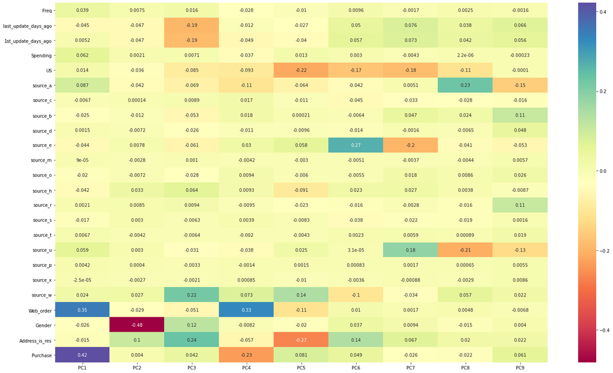

```python
# get correlation matrix plot for loadings
import seaborn as sns
import matplotlib.pyplot as plt

fig, ax = pyplot.subplots(figsize=(25,15))

ax = sns.heatmap(loading_matrix, annot=True, cmap='Spectral')
plt.show()
```

## Split in train and test set

Split the dataset in train, validation and test

```python
from sklearn.model_selection import train_test_split

df_train, temp = train_test_split(scaled_df, test_size=0.60, random_state=1)
df_test, df_validation = train_test_split(temp, test_size=0.583, random_state=1)

print('obs in train data:', df_train.shape[0],', obs in validation data:', df_validation.shape[0], ', obs in test data:', df_test.shape[0] )
```

```
obs in train data: 800 , obs in validation data: 700 , obs in test data: 500
```

Distribution of Purchase = 1 and Purchase = 0 in the datasets The distribution is almost uniform (As we expected) due to the randomization.

```python
 df_1 = pd.DataFrame(df_train.Purchase.value_counts())
df_1 = df_1.rename(columns={'Purchase': 'Purchase_train'})
 df_2 = pd.DataFrame(df_test.Purchase.value_counts())
df_2 = df_2.rename(columns={'Purchase': 'Purchase_test'})
 df_3 = pd.DataFrame(df_validation.Purchase.value_counts())
df_3 = df_3.rename(columns={'Purchase': 'Purchase_validation'})


result = pd.concat([df_1, df_2, df_3], axis=1)
result
```

|  | Purchase_train | Purchase_test | Purchase_validation |
| --- | --- | --- | --- |
| 0 | 411 | 242 | 347 |
| 1 | 389 | 258 | 353 |

## Descriptive statistics for Training, test and validation set

#### training set

```python
pd.set_option('display.max_columns', None)
(df_train.describe())
```

|  | Freq | last_update_days_ago | 1st_update_days_ago | Spending | US | source_a | source_c | source_b | source_d | source_e | source_m | source_o | source_h | source_r | source_s | source_t | source_u | source_p | source_x | source_w | Web_order | Gender | Address_is_res | Purchase |
| --- | --- | --- | --- | --- | --- | --- | --- | --- | --- | --- | --- | --- | --- | --- | --- | --- | --- | --- | --- | --- | --- | --- | --- | --- |
| count | 800.000000 | 800.000000 | 800.000000 | 800.000000 | 800.000000 | 800.000000 | 800.00000 | 800.000000 | 800.000000 | 800.000000 | 800.000000 | 800.000000 | 800.000000 | 800.00000 | 800.00000 | 800.000000 | 800.000000 | 800.000000 | 800.000000 | 800.000000 | 800.00000 | 800.000000 | 800.000000 | 800.000000 |
| mean | 0.096417 | 0.511905 | 0.584741 | 0.068812 | 0.838750 | 0.127500 | 0.06375 | 0.058750 | 0.040000 | 0.176250 | 0.016250 | 0.037500 | 0.043750 | 0.06375 | 0.04875 | 0.022500 | 0.112500 | 0.007500 | 0.017500 | 0.121250 | 0.41500 | 0.505000 | 0.222500 | 0.486250 |
| std | 0.098315 | 0.276642 | 0.257111 | 0.129699 | 0.367991 | 0.333741 | 0.24446 | 0.235303 | 0.196082 | 0.381271 | 0.126515 | 0.190102 | 0.204666 | 0.24446 | 0.21548 | 0.148396 | 0.316178 | 0.086331 | 0.131207 | 0.326622 | 0.49303 | 0.500288 | 0.416185 | 0.500124 |
| min | 0.000000 | 0.003105 | 0.003821 | 0.000000 | 0.000000 | 0.000000 | 0.00000 | 0.000000 | 0.000000 | 0.000000 | 0.000000 | 0.000000 | 0.000000 | 0.00000 | 0.00000 | 0.000000 | 0.000000 | 0.000000 | 0.000000 | 0.000000 | 0.00000 | 0.000000 | 0.000000 | 0.000000 |
| 25% | 0.066667 | 0.267913 | 0.407870 | 0.000000 | 1.000000 | 0.000000 | 0.00000 | 0.000000 | 0.000000 | 0.000000 | 0.000000 | 0.000000 | 0.000000 | 0.00000 | 0.00000 | 0.000000 | 0.000000 | 0.000000 | 0.000000 | 0.000000 | 0.00000 | 0.000000 | 0.000000 | 0.000000 |
| 50% | 0.066667 | 0.538811 | 0.642226 | 0.000000 | 1.000000 | 0.000000 | 0.00000 | 0.000000 | 0.000000 | 0.000000 | 0.000000 | 0.000000 | 0.000000 | 0.00000 | 0.00000 | 0.000000 | 0.000000 | 0.000000 | 0.000000 | 0.000000 | 0.00000 | 1.000000 | 0.000000 | 0.000000 |
| 75% | 0.133333 | 0.754239 | 0.800872 | 0.096833 | 1.000000 | 0.000000 | 0.00000 | 0.000000 | 0.000000 | 0.000000 | 0.000000 | 0.000000 | 0.000000 | 0.00000 | 0.00000 | 0.000000 | 0.000000 | 0.000000 | 0.000000 | 0.000000 | 1.00000 | 1.000000 | 0.000000 | 1.000000 |
| max | 1.000000 | 1.000000 | 1.000000 | 0.928667 | 1.000000 | 1.000000 | 1.00000 | 1.000000 | 1.000000 | 1.000000 | 1.000000 | 1.000000 | 1.000000 | 1.00000 | 1.00000 | 1.000000 | 1.000000 | 1.000000 | 1.000000 | 1.000000 | 1.00000 | 1.000000 | 1.000000 | 1.000000 |

#### validation set

```python
pd.set_option('display.max_columns', None)
(df_validation.describe())
```

|  | Freq | last_update_days_ago | 1st_update_days_ago | Spending | US | source_a | source_c | source_b | source_d | source_e | source_m | source_o | source_h | source_r | source_s | source_t | source_u | source_p | source_x | source_w | Web_order | Gender | Address_is_res | Purchase |
| --- | --- | --- | --- | --- | --- | --- | --- | --- | --- | --- | --- | --- | --- | --- | --- | --- | --- | --- | --- | --- | --- | --- | --- | --- |
| count | 700.000000 | 700.000000 | 700.000000 | 700.000000 | 700.000000 | 700.000000 | 700.000000 | 700.000000 | 700.000000 | 700.000000 | 700.000000 | 700.000000 | 700.000000 | 700.000000 | 700.000000 | 700.000000 | 700.000000 | 700.000000 | 700.0000 | 700.000000 | 700.000000 | 700.000000 | 700.000000 | 700.000000 |
| mean | 0.093810 | 0.510907 | 0.579387 | 0.067235 | 0.812857 | 0.118571 | 0.055714 | 0.061429 | 0.044286 | 0.137143 | 0.015714 | 0.032857 | 0.057143 | 0.071429 | 0.047143 | 0.022857 | 0.117143 | 0.008571 | 0.0200 | 0.144286 | 0.428571 | 0.535714 | 0.215714 | 0.504286 |
| std | 0.093840 | 0.275559 | 0.263182 | 0.119914 | 0.390305 | 0.323515 | 0.229533 | 0.240286 | 0.205876 | 0.344244 | 0.124457 | 0.178390 | 0.232281 | 0.257724 | 0.212096 | 0.149555 | 0.321820 | 0.092250 | 0.1401 | 0.351630 | 0.495226 | 0.499079 | 0.411611 | 0.500339 |
| min | 0.000000 | 0.000000 | 0.000000 | 0.000000 | 0.000000 | 0.000000 | 0.000000 | 0.000000 | 0.000000 | 0.000000 | 0.000000 | 0.000000 | 0.000000 | 0.000000 | 0.000000 | 0.000000 | 0.000000 | 0.000000 | 0.0000 | 0.000000 | 0.000000 | 0.000000 | 0.000000 | 0.000000 |
| 25% | 0.066667 | 0.269346 | 0.392644 | 0.000000 | 1.000000 | 0.000000 | 0.000000 | 0.000000 | 0.000000 | 0.000000 | 0.000000 | 0.000000 | 0.000000 | 0.000000 | 0.000000 | 0.000000 | 0.000000 | 0.000000 | 0.0000 | 0.000000 | 0.000000 | 0.000000 | 0.000000 | 0.000000 |
| 50% | 0.066667 | 0.536900 | 0.652973 | 0.004000 | 1.000000 | 0.000000 | 0.000000 | 0.000000 | 0.000000 | 0.000000 | 0.000000 | 0.000000 | 0.000000 | 0.000000 | 0.000000 | 0.000000 | 0.000000 | 0.000000 | 0.0000 | 0.000000 | 0.000000 | 1.000000 | 0.000000 | 1.000000 |
| 75% | 0.133333 | 0.746119 | 0.802066 | 0.102000 | 1.000000 | 0.000000 | 0.000000 | 0.000000 | 0.000000 | 0.000000 | 0.000000 | 0.000000 | 0.000000 | 0.000000 | 0.000000 | 0.000000 | 0.000000 | 0.000000 | 0.0000 | 0.000000 | 1.000000 | 1.000000 | 0.000000 | 1.000000 |
| max | 0.800000 | 1.000000 | 1.000000 | 1.000000 | 1.000000 | 1.000000 | 1.000000 | 1.000000 | 1.000000 | 1.000000 | 1.000000 | 1.000000 | 1.000000 | 1.000000 | 1.000000 | 1.000000 | 1.000000 | 1.000000 | 1.0000 | 1.000000 | 1.000000 | 1.000000 | 1.000000 | 1.000000 |

#### test set

```python
print(df_test.describe())
```

```
             Freq  last_update_days_ago  1st_update_days_ago    Spending  \
count  500.000000            500.000000           500.000000  500.000000
mean     0.092267              0.523578             0.579140    0.069439
std      0.085787              0.261978             0.250163    0.122616
min      0.000000              0.003344             0.003344    0.000000
25%      0.066667              0.298245             0.394555    0.000000
50%      0.066667              0.556723             0.650227    0.007667
75%      0.133333              0.745940             0.791915    0.106667
max      0.866667              1.000000             1.000000    0.962000

               US    source_a    source_c    source_b    source_d   source_e  \
count  500.000000  500.000000  500.000000  500.000000  500.000000  500.00000
mean     0.818000    0.136000    0.044000    0.060000    0.040000    0.13000
std      0.386231    0.343132    0.205301    0.237725    0.196155    0.33664
min      0.000000    0.000000    0.000000    0.000000    0.000000    0.00000
25%      1.000000    0.000000    0.000000    0.000000    0.000000    0.00000
50%      1.000000    0.000000    0.000000    0.000000    0.000000    0.00000
75%      1.000000    0.000000    0.000000    0.000000    0.000000    0.00000
max      1.000000    1.000000    1.000000    1.000000    1.000000    1.00000

         source_m    source_o    source_h    source_r    source_s    source_t  \
count  500.000000  500.000000  500.000000  500.000000  500.000000  500.000000
mean     0.018000    0.028000    0.060000    0.072000    0.044000    0.018000
std      0.133084    0.165138    0.237725    0.258747    0.205301    0.133084
min      0.000000    0.000000    0.000000    0.000000    0.000000    0.000000
25%      0.000000    0.000000    0.000000    0.000000    0.000000    0.000000
50%      0.000000    0.000000    0.000000    0.000000    0.000000    0.000000
75%      0.000000    0.000000    0.000000    0.000000    0.000000    0.000000
max      1.000000    1.000000    1.000000    1.000000    1.000000    1.000000

        source_u  source_p    source_x   source_w   Web_order      Gender  \
count  500.00000     500.0  500.000000  500.00000  500.000000  500.000000
mean     0.13200       0.0    0.016000    0.15400    0.440000    0.540000
std      0.33883       0.0    0.125601    0.36131    0.496884    0.498897
min      0.00000       0.0    0.000000    0.00000    0.000000    0.000000
25%      0.00000       0.0    0.000000    0.00000    0.000000    0.000000
50%      0.00000       0.0    0.000000    0.00000    0.000000    1.000000
75%      0.00000       0.0    0.000000    0.00000    1.000000    1.000000
max      1.00000       0.0    1.000000    1.00000    1.000000    1.000000

       Address_is_res    Purchase
count      500.000000  500.000000
mean         0.226000    0.516000
std          0.418658    0.500244
min          0.000000    0.000000
25%          0.000000    0.000000
50%          0.000000    1.000000
75%          0.000000    1.000000
max          1.000000    1.000000
```

All the datasets show similar desciptive statistcs

Let's split the dataset in predictors (X) and target vairable (y). We are going to drop also the variable spending to avoid multicollinearity problems.

```python
y_train = df_train.Purchase.copy()
X_train = df_train.drop(['Purchase', 'Spending'], axis=1)

y_validation = df_validation.Purchase.copy()
X_validation = df_validation.drop(['Purchase', 'Spending'], axis=1)

y_test = df_test.Purchase.copy()
X_test = df_test.drop(['Purchase', 'Spending'], axis=1)
```

## Variable selection via REcursive feature eliminaion (RFE)

Let's try to identify the 5 best variables to predict Purchase

To do so we are going to use the Recursive Feature Elimination (RFE). RFE works by searching for a subset of features by starting with all features in the training dataset and successfully removing features until the desired number remains. We'll try to find the best 5 variables

https://machinelearningmastery.com/rfe-feature-selection-in-python/

```python
# test classification dataset
from sklearn.datasets import make_classification
```

```python
# evaluate RFE for classification
from numpy import mean
from numpy import std
from sklearn.datasets import make_classification
from sklearn.model_selection import cross_val_score
from sklearn.model_selection import RepeatedStratifiedKFold
from sklearn.feature_selection import RFE
from sklearn.tree import DecisionTreeClassifier
from sklearn.pipeline import Pipeline
# create pipeline
rfe = RFE(estimator=DecisionTreeClassifier(), n_features_to_select=5)
model = DecisionTreeClassifier()
pipeline = Pipeline(steps=[('s',rfe),('m',model)])
# evaluate model
cv = RepeatedStratifiedKFold(n_splits=10, n_repeats=3, random_state=1)
n_scores = cross_val_score(pipeline, X_train, y_train, scoring='accuracy', cv=cv, n_jobs=-1, error_score='raise')
# report performance
print('Accuracy: %.3f (%.3f)' % (mean(n_scores), std(n_scores)))
```

```
Accuracy: 0.763 (0.044)
```

```python
# fit RFE
rfe.fit(X_train, y_train)
# summarize all features
for i in range(X_train.shape[1]):
    print('Column: %d, Selected %s, Rank: %.3f' % (i, rfe.support_[i], rfe.ranking_[i]))
```

```
Column: 0, Selected True, Rank: 1.000
Column: 1, Selected True, Rank: 1.000
Column: 2, Selected True, Rank: 1.000
Column: 3, Selected True, Rank: 1.000
Column: 4, Selected False, Rank: 2.000
Column: 5, Selected False, Rank: 11.000
Column: 6, Selected False, Rank: 8.000
Column: 7, Selected False, Rank: 17.000
Column: 8, Selected False, Rank: 10.000
Column: 9, Selected False, Rank: 15.000
Column: 10, Selected False, Rank: 14.000
Column: 11, Selected True, Rank: 1.000
Column: 12, Selected False, Rank: 7.000
Column: 13, Selected False, Rank: 9.000
Column: 14, Selected False, Rank: 18.000
Column: 15, Selected False, Rank: 4.000
Column: 16, Selected False, Rank: 16.000
Column: 17, Selected False, Rank: 13.000
Column: 18, Selected False, Rank: 6.000
Column: 19, Selected False, Rank: 3.000
Column: 20, Selected False, Rank: 12.000
Column: 21, Selected False, Rank: 5.000
```

```python
pd.DataFrame(X_train.columns)
```

|  | 0 |
| --- | --- |
| 0 | Freq |
| 1 | last_update_days_ago |
| 2 | 1st_update_days_ago |
| 3 | US |
| 4 | source_a |
| 5 | source_c |
| 6 | source_b |
| 7 | source_d |
| 8 | source_e |
| 9 | source_m |
| 10 | source_o |
| 11 | source_h |
| 12 | source_r |
| 13 | source_s |
| 14 | source_t |
| 15 | source_u |
| 16 | source_p |
| 17 | source_x |
| 18 | source_w |
| 19 | Web_order |
| 20 | Gender |
| 21 | Address_is_res |

```python
import sklearn

# evaluate RFE for classification
from numpy import mean
from numpy import std
from sklearn.datasets import make_classification
from sklearn.model_selection import cross_val_score
from sklearn.model_selection import RepeatedStratifiedKFold
from sklearn.feature_selection import RFE
from sklearn.tree import DecisionTreeClassifier
from sklearn.pipeline import Pipeline
# create pipeline
rfe = RFE(estimator=DecisionTreeClassifier(), n_features_to_select=5)
model = DecisionTreeClassifier()
pipeline = Pipeline(steps=[('s',rfe),('m',model)])
# evaluate model
cv = RepeatedStratifiedKFold(n_splits=10, n_repeats=3, random_state=1)
n_scores = cross_val_score(pipeline, X_train, y_train, scoring='accuracy', cv=cv, n_jobs=-1, error_score='raise')
# report performance
print('Accuracy: %.3f (%.3f)' % (mean(n_scores), std(n_scores)))
```

```
Accuracy: 0.762 (0.043)
```

The best 5 variables to predict the variable 'Purchase' are :

[output not shown]

Let's create the 5 variable dataset

```python
X_log = X_train[["Freq", "1st_update_days_ago", "last_update_days_ago", "source_h", "source_a"]]

X_log_t= X_test[["Freq", "1st_update_days_ago", "last_update_days_ago", "source_h", "source_a"]]

X_log_v= X_validation[["Freq", "1st_update_days_ago", "last_update_days_ago", "source_h", "source_a"]]
X_log_v
```

|  | Freq | 1st_update_days_ago | last_update_days_ago | source_h | source_a |
| --- | --- | --- | --- | --- | --- |
| 159 | 0.200000 | 0.565560 | 0.483162 | 0 | 1 |
| 703 | 0.066667 | 0.145211 | 0.145211 | 0 | 0 |
| 320 | 0.133333 | 0.949128 | 0.830666 | 0 | 1 |
| 382 | 0.000000 | 0.812037 | 0.812037 | 0 | 0 |
| 830 | 0.066667 | 0.221877 | 0.221877 | 0 | 0 |
| ... | ... | ... | ... | ... | ... |
| 1273 | 0.133333 | 0.782661 | 0.774301 | 0 | 0 |
| 460 | 0.066667 | 0.711010 | 0.710771 | 0 | 0 |
| 1650 | 0.000000 | 0.652973 | 0.652973 | 0 | 0 |
| 1441 | 0.066667 | 0.818963 | 0.818963 | 0 | 0 |
| 587 | 0.133333 | 0.956293 | 0.934559 | 0 | 1 |

700 rows × 5 columns

### Logit model with Statsmodels and RFE variables

```python
# importing libraries
import statsmodels.api as sm
import pandas as pd
import numpy as np
```

```python
# # defining the dependent and independent variables

X_log = np.array(X_log)
y_train =  np.array(y_train)
# building the model and fitting the data
log_reg = sm.Logit(y_train, X_log).fit()
```

```
Optimization terminated successfully.
         Current function value: 0.502525
         Iterations 7
```

Summary of the model

```python
# printing the summary table
print(log_reg.summary())
```

```
                           Logit Regression Results
==============================================================================
Dep. Variable:                      y   No. Observations:                  800
Model:                          Logit   Df Residuals:                      795
Method:                           MLE   Df Model:                            4
Date:                Sat, 06 Mar 2021   Pseudo R-squ.:                  0.2746
Time:                        13:18:20   Log-Likelihood:                -402.02
converged:                       True   LL-Null:                       -554.22
Covariance Type:            nonrobust   LLR p-value:                 1.224e-64
==============================================================================
                 coef    std err          z      P>|z|      [0.025      0.975]
------------------------------------------------------------------------------
x1            17.6353      1.689     10.440      0.000      14.325      20.946
x2            -1.0547      0.846     -1.247      0.212      -2.712       0.603
x3            -1.3179      0.810     -1.628      0.104      -2.905       0.269
x4            -4.1943      0.663     -6.328      0.000      -5.493      -2.895
x5             1.2326      0.293      4.202      0.000       0.658       1.808
==============================================================================
```

### Performance on validation set

```python
y_pred = log_reg.predict(X_log_v)
y_pred
y_pred = list(map(round, y_pred))
y_val_pred = y_pred.copy

# print('Accuracy of logistic regression classifier on test set: {:.2f}'.format(logreg.score(X_log_v, y_validation)))
```

```python
y_prob_val = log_reg.predict(X_log_v)

print('as you can see here we got probabilities')
y_prob_val.head()
```

```
as you can see here we got probabilities
```

```
159    0.971429
703    0.696600
320    0.815802
382    0.127122
830    0.656844
dtype: float64
```

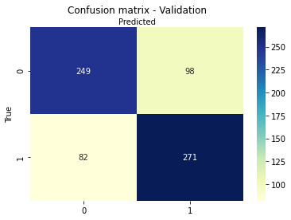

```python
import sklearn.metrics as metrics
import numpy as np
from sklearn.metrics import confusion_matrix
import seaborn as sns


cnf_matrix = metrics.confusion_matrix(y_validation, y_pred)


labels = [0, 1]
fig, ax = plt.subplots()
tick_marks = np.arange(len(labels))
plt.xticks(tick_marks, labels)
plt.yticks(tick_marks, labels)
# create heatmap
sns.heatmap(pd.DataFrame(cnf_matrix), annot=True, cmap="YlGnBu", fmt='g')
ax.xaxis.set_label_position("top")
plt.title('Confusion matrix - Validation', y=1.1)
plt.ylabel('True')
plt.xlabel('Predicted')
```

```python
print('Accuracy on validation Set', round((249+271)/(249+271+98+82), 2))
```

```
Accuracy on validation Set 0.74
```

### Score Analysis

Adjusted probabilities

```python
y_adjusted_prob_v = y_prob_val * 0.107
y_adjusted_prob_v.head()
y_adjusted_prob_v = pd.DataFrame(y_adjusted_prob_v).reset_index(drop=True)
y_adjusted_prob_v['pred'] = y_pred
y_adjusted_prob_v['True'] = y_validation
y_adjusted_prob_v.columns = ['Adjusted_prob', 'Predicted_prob', 'True_Value']
y_adjusted_prob_v.head()
```

|  | Adjusted_prob | Predicted_prob | True_Value |
| --- | --- | --- | --- |
| 0 | 0.103943 | 1 | 1 |
| 1 | 0.074536 | 1 | 1 |
| 2 | 0.087291 | 1 | 1 |
| 3 | 0.013602 | 0 | 0 |
| 4 | 0.070282 | 1 | 0 |

### Gain and lift Chart for the validation set

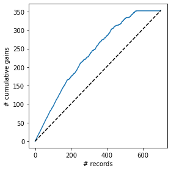

```python
from dmba import regressionSummary, classificationSummary, liftChart, gainsChart

y_pred = log_reg.predict(X_log_v)
y_pred
y_pred.values

column_names = ["Prob", "actual"]

df = pd.DataFrame(columns = column_names)
df["Prob"] = y_pred.values
df["actual"] = y_validation
df = df.sort_values(by=['Prob'], ascending=False)

gainsChart(df.actual, figsize=(4, 4))

plt.tight_layout()
plt.show()
# print('Accuracy of logistic regression classifier on test set: {:.2f}'.format(logreg.score(X_log_v, y_validation)))
```

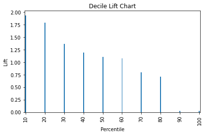

```python
liftChart(df.actual, labelBars=False)
plt.tight_layout()
plt.show()
```

### Performance on Test set

```python
y_pred = log_reg.predict(X_log_t)
y_pred
y_pred = list(map(round, y_pred))
y_pred_test = y_pred.copy
# print('Accuracy of logistic regression classifier on test set: {:.2f}'.format(logreg.score(X_log_t, y_test)))
```

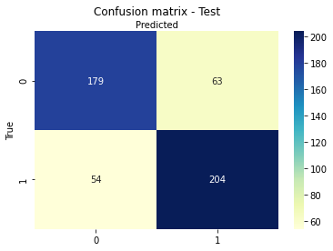

```python
cnf_matrix = metrics.confusion_matrix(y_test, y_pred)


labels = [0, 1]
fig, ax = plt.subplots()
tick_marks = np.arange(len(labels))
plt.xticks(tick_marks, labels)
plt.yticks(tick_marks, labels)
# create heatmap
sns.heatmap(pd.DataFrame(cnf_matrix), annot=True, cmap="YlGnBu", fmt='g')
ax.xaxis.set_label_position("top")
plt.title('Confusion matrix - Test', y=1.1)
plt.ylabel('True')
plt.xlabel('Predicted')
```

```python
print('accuracy on test set', round((179+204)/(179+204+63+54), 2))
```

```
accuracy on test set 0.77
```

```python
y_test_prob = log_reg.predict(X_log_t)
y_test_prob = y_test_prob * 0.107
y_test_prob.head()
```

```
1089    0.039237
1874    0.090351
1707    0.066197
790     0.042401
608     0.043388
dtype: float64
```

```python
y_test_prob
```

```
1089    0.039237
1874    0.090351
1707    0.066197
790     0.042401
608     0.043388
          ...
1766    0.041157
1654    0.098091
479     0.086418
1051    0.006321
326     0.006465
Length: 500, dtype: float64
```

### Score Analysis

```python
y_adjusted_prob_t = y_test_prob
y_adjusted_prob_t = pd.DataFrame(y_adjusted_prob_t).reset_index(drop=True)
y_adjusted_prob_t['pred'] = y_pred
y_adjusted_prob_t['True'] = y_test
y_adjusted_prob_t.columns = ['Adjusted_prob', 'Predicted_prob', 'True_Value']
y_adjusted_prob_t.head()
```

|  | Adjusted_prob | Predicted_prob | True_Value |
| --- | --- | --- | --- |
| 0 | 0.039237 | 0 | 0 |
| 1 | 0.090351 | 1 | 1 |
| 2 | 0.066197 | 1 | 0 |
| 3 | 0.042401 | 0 | 0 |
| 4 | 0.043388 | 0 | 0 |

#### Gain and Lift Chart for the Test Set

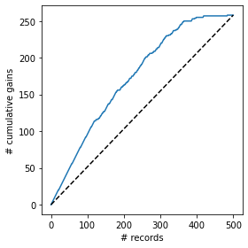

```python
from dmba import regressionSummary, classificationSummary, liftChart, gainsChart

y_pred = log_reg.predict(X_log_t)
y_pred
y_pred.values

column_names = ["Prob", "actual"]

df = pd.DataFrame(columns = column_names)
df["Prob"] = y_pred.values
df["actual"] = y_test
df = df.sort_values(by=['Prob'], ascending=False)

gainsChart(df.actual, figsize=(4, 4))

plt.tight_layout()
plt.show()
# print('Accuracy of logistic regression classifier on test set: {:.2f}'.format(logreg.score(X_log_v, y_validation)))
```

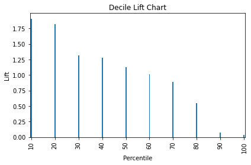

```python
liftChart(df.actual, labelBars=False)
plt.tight_layout()
plt.show()
```

# Logit using L2 penalty and 10-CV

Now we'll create a logistic regression that uses the L2 penalty (also calld Ridge Regression) and a 10 fold Cross-Validation. We need to use the Ridge regression because it adds “squared magnitude” of coefficient as penalty term to the loss function.

```python
from sklearn.ensemble import RandomForestClassifier
from sklearn.linear_model import LogisticRegressionCV
from sklearn.model_selection import train_test_split
from sklearn.model_selection import StratifiedShuffleSplit
from sklearn.metrics import accuracy_score
```

Accuracy on training data

```python
clf = LogisticRegressionCV(max_iter=200, cv=10, penalty='l2')
clf.fit(X_log, y_train)
train_predictions = clf.predict(X_log)
train_predictions
acc = accuracy_score(y_train, train_predictions)
print(acc)
```

```
0.76875
```

```python
train_predictions
```

[output not shown]

[output cut: 22 more lines]

Coefficients from the model obtained via cross-validation.

```python
num = clf.fit(X_log, y_train).coef_
pd.DataFrame(num)
```

|  | 0 | 1 | 2 | 3 | 4 |
| --- | --- | --- | --- | --- | --- |
| 0 | 30.472307 | -0.650372 | 0.694432 | -4.623592 | 1.136239 |

### Performance on test set

```python
y_pred = pd.Series(clf.predict(X_log_t))
y_test = y_test.reset_index(drop=True)
z = pd.concat([y_test, y_pred], axis=1)
z.columns = ['True', 'Prediction']
z.head()
```

|  | True | Prediction |
| --- | --- | --- |
| 0 | 0 | 0 |
| 1 | 1 | 1 |
| 2 | 0 | 1 |
| 3 | 0 | 0 |
| 4 | 0 | 0 |

```python
print('Accuracy of logistic regression classifier on test set: {:.2f}'.format(clf.score(X_log_t, y_test)))
```

```
Accuracy of logistic regression classifier on test set: 0.77
```

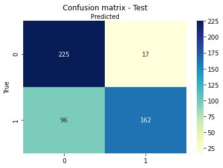

```python
cnf_matrix = metrics.confusion_matrix(y_test, y_pred)

labels = [0, 1]
fig, ax = plt.subplots()
tick_marks = np.arange(len(labels))
plt.xticks(tick_marks, labels)
plt.yticks(tick_marks, labels)
# create heatmap
sns.heatmap(pd.DataFrame(cnf_matrix), annot=True, cmap="YlGnBu", fmt='g')
ax.xaxis.set_label_position("top")
plt.title('Confusion matrix - Test', y=1.1)
plt.ylabel('True')
plt.xlabel('Predicted')
```

### Performance on validation Set

```python
print('Accuracy of logistic regression classifier on validation set: {:.2f}'.format(clf.score(X_log_v, y_validation)))
```

```
Accuracy of logistic regression classifier on validation set: 0.75
```

```python
y_pred = pd.Series(clf.predict(X_log_v))
y_validation = y_validation.reset_index(drop=True)
z = pd.concat([y_validation, y_pred], axis=1)
z.columns = ['True', 'Prediction']
z.head()
```

|  | True | Prediction |
| --- | --- | --- |
| 0 | 1 | 1 |
| 1 | 1 | 0 |
| 2 | 1 | 1 |
| 3 | 0 | 0 |
| 4 | 0 | 0 |

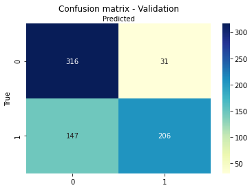

```python
cnf_matrix = metrics.confusion_matrix(y_validation, y_pred)

labels = [0, 1]
fig, ax = plt.subplots()
tick_marks = np.arange(len(labels))
plt.xticks(tick_marks, labels)
plt.yticks(tick_marks, labels)
# create heatmap
sns.heatmap(pd.DataFrame(cnf_matrix), annot=True, cmap="YlGnBu", fmt='g')
ax.xaxis.set_label_position("top")
plt.title('Confusion matrix - Validation', y=1.1)
plt.ylabel('True')
plt.xlabel('Predicted')
```